# Marovoay–Ankarafantsika: Extended Econometric Analysis

Author

BETSAKA project

Published

March 10, 2026

# Marovoay–Ankarafantsika: Extended Econometric Analysis

This document extends the analysis in `04_Marovoay-Ankarafantsika.qmd` by implementing alternative causal inference methods, incorporating the 2025 survey wave, and expanding the donor pool to the Alaotra observatory sites. For the full methodological rationale, see `documentation/05_econometric_review.md`.

**WarningPreliminary results**

All results are provisional. Variable construction, outlier treatment, and model specification require further validation before any substantive interpretation.

## 1 Panel Construction

### 1.1 Historical household panel (1995–2015)

The historical panel is built from `data/household_consolidated.rds`.

**Note on 2005:** The 2005 Marovoay survey was a tracking survey that covered only a non-representative subset of households (site 032/Madiromiongana was not surveyed, and the other sites had atypical composition). **Year 2005 is excluded from all specifications.**

```r
household_consolidated <- read_rds("data/household_consolidated.rds")

panel_hh_hist <- household_consolidated |>
  mutate(
    obs      = substr(j5, 1, 2),
    site_id  = substr(j5, 1, 3),
    treated_unit = site_id %in% MARO_TREATED,
    post         = year >= TREAT_YEAR,
    treatment    = as.integer(treated_unit & post)
  ) |>
  mutate(
    rev_riz  = coalesce(rev_riz,  0),
    rev_cu   = coalesce(rev_cu,   0),
    revel    = coalesce(revel,    0),
    revpeche = coalesce(revpeche, 0),
    revppal  = coalesce(revppal,  0),
    revsec   = coalesce(revsec,   0),
    revcou   = coalesce(revcou, revppal + revsec + rev_riz + rev_cu + revel + revpeche),
    rev_agri    = rev_riz + rev_cu + revel + revpeche,
    rev_nonagri = revppal + revsec,
    across(c(revtot, revcou, rev_agri, rev_nonagri),
           ~ pmin(.x, quantile(.x, 0.99, na.rm = TRUE)), .names = "{.col}_w"),
    across(ends_with("_w"), ~ log(.x + 1), .names = "ln_{.col}")
  ) |>
  distinct(j5, year, .keep_all = TRUE) |>
  # Exclude atypical 2005 Marovoay tracking survey
  filter(!(obs == "03" & year == 2005))
```

### 1.2 Adding the 2025 wave — Marovoay

Marovoay 2025 households are identified by `j0 == 3` in `res_deb.dta`. Site assignment uses `fix_hameau(j4)` to map hamlet name strings to the four canonical site codes (031–034). Income is sourced from `output/ref_incomes_snapshot.rds` matched on `j5`. Note that `res_v.dta` is the assets module (radio, bicycle…), **not** income — do not confuse the two.

```r
res_deb_25 <- read_dta("data/res_deb.dta") |>
  mutate(j5 = as.character(j5), j0 = as.character(j0))

# Income snapshot includes 2025 via compute_income_all_years()
rev_2025 <- read_rds("output/ref_incomes_snapshot.rds") |>
  mutate(j5 = as.character(j5)) |>
  filter(year == 2025)

# Marovoay 2025: j0 == "3", site assigned via fix_hameau(j4)
maro_25_ids <- res_deb_25 |>
  filter(j0 == "3") |>
  mutate(
    site_id = case_when(
      str_starts(str_to_lower(j4), "bepako")          ~ "031",
      str_starts(str_to_lower(j4), "madiromiongana")  ~ "032",
      str_starts(str_to_lower(j4), "ampijoroa")       ~ "033",
      str_starts(str_to_lower(j4), "maroala")         ~ "034",
      TRUE ~ NA_character_
    ),
    obs = "03"
  ) |>
  select(j5, obs, site_id)

panel_maro_25 <- maro_25_ids |>
  left_join(rev_2025, by = "j5") |>
  mutate(
    year = 2025,
    rev_riz  = coalesce(rev_riz,  0),
    rev_cu   = coalesce(rev_cu,   0),
    revel    = coalesce(revel,    0),
    revpeche = coalesce(revpeche, 0),
    revppal  = coalesce(revppal,  0),
    revsec   = coalesce(revsec,   0),
    revcou   = coalesce(revcou, revppal + revsec + rev_riz + rev_cu + revel + revpeche),
    revtot   = coalesce(revtot, revcou),
    rev_agri    = rev_riz + rev_cu + revel + revpeche,
    rev_nonagri = revppal + revsec,
    treated_unit = site_id %in% MARO_TREATED,
    post         = TRUE,
    treatment    = as.integer(treated_unit)
  ) |>
  mutate(
    across(c(revtot, revcou, rev_agri, rev_nonagri),
           ~ pmin(.x, quantile(.x, 0.99, na.rm = TRUE)), .names = "{.col}_w"),
    across(ends_with("_w"), ~ log(.x + 1), .names = "ln_{.col}")
  )
```

### 1.3 Adding the 2025 wave — Alaotra

Alaotra 2025 households are identified by `j0 == 21`. Site codes are the first 3 digits of `j5` (211–215). The same income snapshot is used.

```r
alaotra_25_ids <- res_deb_25 |>
  filter(j0 == "21") |>
  mutate(site_id = substr(j5, 1, 3), obs = "21") |>
  select(j5, obs, site_id)

panel_alaotra_25 <- alaotra_25_ids |>
  left_join(rev_2025, by = "j5") |>
  mutate(
    year = 2025,
    rev_riz  = coalesce(rev_riz,  0),
    rev_cu   = coalesce(rev_cu,   0),
    revel    = coalesce(revel,    0),
    revpeche = coalesce(revpeche, 0),
    revppal  = coalesce(revppal,  0),
    revsec   = coalesce(revsec,   0),
    revcou   = coalesce(revcou, revppal + revsec + rev_riz + rev_cu + revel + revpeche),
    revtot   = coalesce(revtot, revcou),
    rev_agri    = rev_riz + rev_cu + revel + revpeche,
    rev_nonagri = revppal + revsec,
    treated_unit = FALSE,
    post         = TRUE,
    treatment    = 0L
  ) |>
  mutate(
    across(c(revtot, revcou, rev_agri, rev_nonagri),
           ~ pmin(.x, quantile(.x, 0.99, na.rm = TRUE)), .names = "{.col}_w"),
    across(ends_with("_w"), ~ log(.x + 1), .names = "ln_{.col}")
  )
```

### 1.4 Combined panels

Three analytical datasets are constructed:

- **`panel_maro`**: Marovoay only (1998–2014 + 2025, 2005 excluded), HH level
- **`panel_expanded`**: Marovoay + Alaotra (historical + 2025), HH level
- **`panel_site_maro`** / **`panel_site_expanded`**: Site-year aggregates for SC estimators

```r
# ── Marovoay-only panel ───────────────────────────────────────────────────────
panel_maro <- bind_rows(
  panel_hh_hist |> filter(obs == "03"),
  panel_maro_25
) |>
  filter(site_id %in% MARO_ALL, year >= 1998)

# ── Expanded panel (Marovoay + Alaotra) ───────────────────────────────────────
panel_expanded <- bind_rows(
  panel_hh_hist |>
    filter(obs %in% c("03","21")) |>
    mutate(treated_unit = site_id %in% MARO_TREATED,
           post         = year >= TREAT_YEAR,
           treatment    = as.integer(treated_unit & post)),
  panel_maro_25,
  panel_alaotra_25
) |>
  filter(
    (obs == "03" & site_id %in% MARO_ALL     & year >= 1998) |
    (obs == "21" & site_id %in% ALAOTRA_ALL  & year >= 1999)
  )

# ── Site-year aggregation helper ─────────────────────────────────────────────
make_site_panel <- function(df) {
  df |>
    group_by(obs, site_id, year, treated_unit, post, treatment) |>
    summarise(
      ln_revtot_w      = mean(ln_revtot_w,      na.rm = TRUE),
      ln_revcou_w      = mean(ln_revcou_w,       na.rm = TRUE),
      ln_rev_agri_w    = mean(ln_rev_agri_w,     na.rm = TRUE),
      ln_rev_nonagri_w = mean(ln_rev_nonagri_w,  na.rm = TRUE),
      share_agri       = mean(
        if_else(revcou > 0, rev_agri / revcou, NA_real_), na.rm = TRUE),
      n_hh             = n(),
      .groups = "drop"
    )
}

panel_site_maro     <- make_site_panel(panel_maro)
panel_site_expanded <- make_site_panel(panel_expanded)

# Balanced subsets (years where all sites within each panel are observed)
balance_years <- function(site_panel) {
  n_expected <- n_distinct(site_panel$site_id)
  site_panel |>
    group_by(year) |>
    filter(n() == n_expected) |>
    ungroup()
}

panel_site_maro_bal     <- balance_years(panel_site_maro)
panel_site_expanded_bal <- balance_years(panel_site_expanded)
```

## 2 Panel Diagnostics

### 2.1 Site distance to nearest protected area

The table below reproduces the output of `distance_sites_pa.R`: distances from each fokontany centroid to the nearest PA boundary (WDPA polygons).

```r
sites_dist <- tribble(
  ~Observatory, ~Fokontany,           ~site_id, ~nearest_pa,                   ~dist_nearest_km, ~dist_anka_km,
  "Marovoay",  "Bepako",              "031",    "Ankarafantsika (PN)",           5.25,  5.25,
  "Marovoay",  "Maroala",             "034",    "Ankarafantsika (PN)",           5.61,  5.61,
  "Marovoay",  "Ampijoroa",           "033",    "Andrefana Dry Forests (WHS)",  11.3,  11.3,
  "Marovoay",  "Madiromiongana",      "032",    "Ankarafantsika (PN)",          11.7,  11.7,
  "Alaotra",   "Maritampona",         "213",    "Lac Alaotra (Paysage)",         8.85,  NA,
  "Alaotra",   "Analamiranga",        "213",    "Lac Alaotra (Paysage)",         9.49,  NA,
  "Alaotra",   "Avaradrano",          "211",    "Lac Alaotra (Paysage)",        10.5,   NA,
  "Alaotra",   "Mangabe",             "212",    "Corridor Ankeniheny (RB)",     14.0,   NA,
  "Alaotra",   "Feramanga Atsimo",    "215",    "Lac Alaotra (Paysage)",        14.8,   NA,
  "Alaotra",   "Ambohidrony",         "214",    "Lac Alaotra (Paysage)",        14.8,   NA,
  "Alaotra",   "Ambatomanga",         "214",    "Lac Alaotra (Paysage)",        16.3,   NA
)

sites_dist |>
  gt(groupname_col = "Observatory") |>
  fmt_number(columns = c(dist_nearest_km, dist_anka_km), decimals = 1) |>
  cols_label(
    Fokontany       = "Fokontany",
    site_id         = "Site ID",
    nearest_pa      = "Nearest PA",
    dist_nearest_km = "Dist. nearest PA (km)",
    dist_anka_km    = "Dist. Ankarafantsika (km)"
  ) |>
  tab_style(style = cell_fill(color = "#FFE5E5"),
            locations = cells_body(rows = dist_nearest_km <= 10)) |>
  tab_style(
    style = list(cell_text(weight = "bold"), cell_fill(color = "#DCDCDC")),
    locations = cells_column_labels()
  ) |>
  tab_style(style = cell_text(weight = "bold"), locations = cells_row_groups()) |>
  tab_footnote("Shaded: within 10 km of nearest PA boundary.",
               locations = cells_column_labels(dist_nearest_km)) |>
  tab_source_note(md("Source: `distance_sites_pa.R` using WDPA polygons (excl. Ramsar/UNESCO)."))
```

Distance from fokontany centroids to nearest PA boundary

| Fokontany | Site ID | Nearest PA | Dist. nearest PA (km)<sup>1</sup> | Dist. Ankarafantsika (km) |
| --- | --- | --- | --- | --- |
| Marovoay |  |  |  |  |
| Bepako | 031 | Ankarafantsika (PN) | 5.2 | 5.2 |
| Maroala | 034 | Ankarafantsika (PN) | 5.6 | 5.6 |
| Ampijoroa | 033 | Andrefana Dry Forests (WHS) | 11.3 | 11.3 |
| Madiromiongana | 032 | Ankarafantsika (PN) | 11.7 | 11.7 |
| Alaotra |  |  |  |  |
| Maritampona | 213 | Lac Alaotra (Paysage) | 8.8 | NA |
| Analamiranga | 213 | Lac Alaotra (Paysage) | 9.5 | NA |
| Avaradrano | 211 | Lac Alaotra (Paysage) | 10.5 | NA |
| Mangabe | 212 | Corridor Ankeniheny (RB) | 14.0 | NA |
| Feramanga Atsimo | 215 | Lac Alaotra (Paysage) | 14.8 | NA |
| Ambohidrony | 214 | Lac Alaotra (Paysage) | 14.8 | NA |
| Ambatomanga | 214 | Lac Alaotra (Paysage) | 16.3 | NA |

<sup>1</sup> Shaded: within 10 km of nearest PA boundary.  
Source: `distance_sites_pa.R` using WDPA polygons (excl. Ramsar/UNESCO).

**Key observations:**

- Bepako (031) and Maroala (034) are the **closest to Ankarafantsika** (5–6 km). Maroala is coded as control — its proximity suggests possible spillover contamination.
- Madiromiongana (032, treated) is 11.7 km — similar to Ampijoroa (033, control) at 11.3 km. The distance-based treatment classification is therefore imperfect.
- **Alaotra sites** are 9–16 km from Lac Alaotra PA, a different PA designated in 2007 (post-treatment). Alaotra sites are plausibly unaffected by the 2002 Ankarafantsika reclassification, supporting their use as controls.

### 2.2 Coverage heatmap — Marovoay

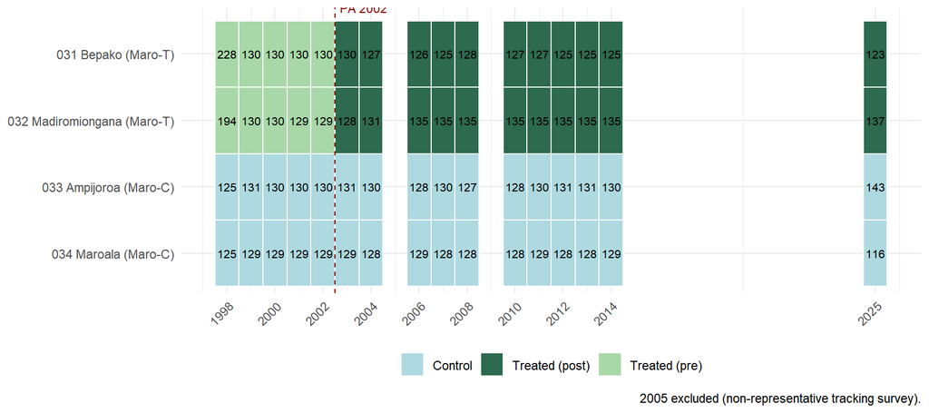

Panel coverage: Marovoay site-year observations (1998–2025, 2005 excluded)

```r
panel_site_maro |>
  mutate(
    site_label = site_labels[site_id],
    Status = case_when(
      treated_unit & post  ~ "Treated (post)",
      treated_unit & !post ~ "Treated (pre)",
      TRUE                  ~ "Control"
    )
  ) |>
  ggplot(aes(x = year, y = fct_rev(site_label), fill = Status)) +
  geom_tile(color = "white", linewidth = 0.5) +
  geom_text(aes(label = n_hh), size = 2.8, color = "black") +
  scale_fill_manual(
    values = c("Treated (pre)" = "#A8D8A8", "Treated (post)" = "#2D6A4F",
               "Control" = "#AED9E0"),
    na.value = "grey90"
  ) +
  scale_x_continuous(breaks = c(seq(1998, 2014, 2), 2025)) +
  geom_vline(xintercept = 2002.5, linetype = "dashed", color = "darkred") +
  annotate("text", x = 2002.5, y = 4.7, label = "PA 2002",
           hjust = -0.1, size = 3, color = "darkred") +
  labs(x = NULL, y = NULL, fill = NULL,
       caption = "2005 excluded (non-representative tracking survey).") +
  theme_minimal() +
  theme(axis.text.x = element_text(angle = 45, hjust = 1),
        legend.position = "bottom")
```

### 2.3 Coverage heatmap — Expanded (Marovoay + Alaotra)

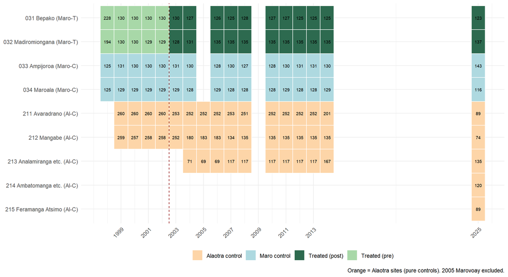

Panel coverage: Marovoay + Alaotra site-year observations

```r
panel_site_expanded |>
  mutate(
    site_label = coalesce(site_labels[site_id], site_id),
    Status = case_when(
      treated_unit & post  ~ "Treated (post)",
      treated_unit & !post ~ "Treated (pre)",
      !treated_unit & obs == "03" ~ "Maro control",
      TRUE                 ~ "Alaotra control"
    )
  ) |>
  ggplot(aes(x = year, y = fct_rev(site_label), fill = Status)) +
  geom_tile(color = "white", linewidth = 0.5) +
  geom_text(aes(label = n_hh), size = 2.4, color = "black") +
  scale_fill_manual(
    values = c("Treated (pre)" = "#A8D8A8", "Treated (post)" = "#2D6A4F",
               "Maro control" = "#AED9E0", "Alaotra control" = "#FDD5A8"),
    na.value = "grey90"
  ) +
  scale_x_continuous(breaks = c(seq(1999, 2014, 2), 2025)) +
  geom_vline(xintercept = 2002.5, linetype = "dashed", color = "darkred") +
  labs(x = NULL, y = NULL, fill = NULL,
       caption = "Orange = Alaotra sites (pure controls). 2005 Marovoay excluded.") +
  theme_minimal() +
  theme(axis.text.x = element_text(angle = 45, hjust = 1),
        legend.position = "bottom")
```

### 2.4 Raw outcome trajectories

```
`geom_line()`: Each group consists of only one observation.
ℹ Do you need to adjust the group aesthetic?
```

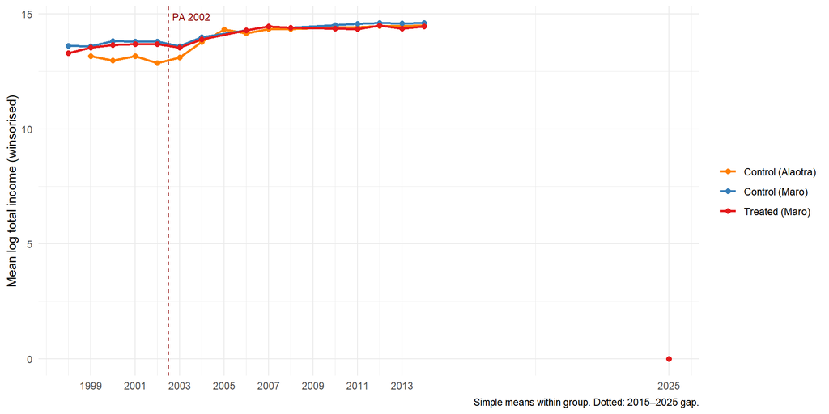

Site-year mean log total income — Marovoay and Alaotra

```r
panel_site_expanded |>
  mutate(Group = case_when(
    treated_unit ~ "Treated (Maro)",
    obs == "03"  ~ "Control (Maro)",
    TRUE         ~ "Control (Alaotra)"
  )) |>
  group_by(Group, year) |>
  summarise(mean_ln = mean(ln_revtot_w, na.rm = TRUE), .groups = "drop") |>
  mutate(in_gap = year > 2015) |>
  ggplot(aes(x = year, y = mean_ln, color = Group, group = Group)) +
  geom_line(data = ~ filter(.x, !in_gap), linewidth = 0.9) +
  geom_line(data = ~ filter(.x, in_gap | year == 2015), linetype = "31", linewidth = 0.9) +
  geom_point(size = 2) +
  geom_vline(xintercept = 2002.5, linetype = "dashed", color = "darkred") +
  annotate("text", x = 2002.5, y = Inf, hjust = -0.1, vjust = 1.8,
           label = "PA 2002", size = 3, color = "darkred") +
  scale_x_continuous(breaks = c(seq(1999, 2014, 2), 2025)) +
  scale_color_manual(values = c(
    "Treated (Maro)"    = "#E41A1C",
    "Control (Maro)"    = "#377EB8",
    "Control (Alaotra)" = "#FF7F00"
  )) +
  labs(x = NULL, y = "Mean log total income (winsorised)", color = NULL,
       caption = "Simple means within group. Dotted: 2015–2025 gap.") +
  theme_minimal()
```